# Week11_Friday slides

## Week 11 Friday

Friday, April 10, 2026

**Announcements**

- A08 (project proposal) due 4/17 **Goals**
- "A*" (A-star) path planning
- Class exercise: Romi path following

## A-Star: Improving Dijkstra's algorithm

Notes based on [this blog post](https://realitybytes.blog/2018/08/17/graph-based-path-planning-a/)

- Dijkstra is "naive" about expansion
- A* (A-star) prefers expansions that get us closer to the goal:
  - A "Heuristic Function" assigns an extra cost to a possible expansion node:
    - $H(x_n,y_n) = \sqrt{(x_g-x_n)^2+(y_g-y_n)^2}\leftarrow$ Euclidean Distance, OR
    - $H(x_n,y_n) = \left|x_g-x_n\right|+\left|y_g-y_n\right|\leftarrow$ Manhattan Distance

## A-Star: Improving Dijkstra's algorithm

Notes based on [this blog post](https://realitybytes.blog/2018/08/17/graph-based-path-planning-a/)

**A-Star Can then be implemented as:**

- For each node, n, in the graph:
  - n.distance = Infinity, n.g = Infinity
- Create an empty list
  - start.distance = 0
  - start.f=H(start)
  - add start to list
- While list not empty:
  - Let current = node in the list with the smallest f value, remove current from list
  - If (current == goal) return Success
  - For each node, n that is adjacent to current:
    - if n.g > (current.g + cost of edge from n to current
      - n.g= current.g+ cost of edge from n to current
      - n.f = n.g + H(n)
      - n.parent = current
      - Add n to list if it is not there already

## Class Exercise: Follow a path generated by dijkstra (or A-star)!

The Week11_InClass world and Week11_Starter controller implement Dijkstra to generate a path to a goal.

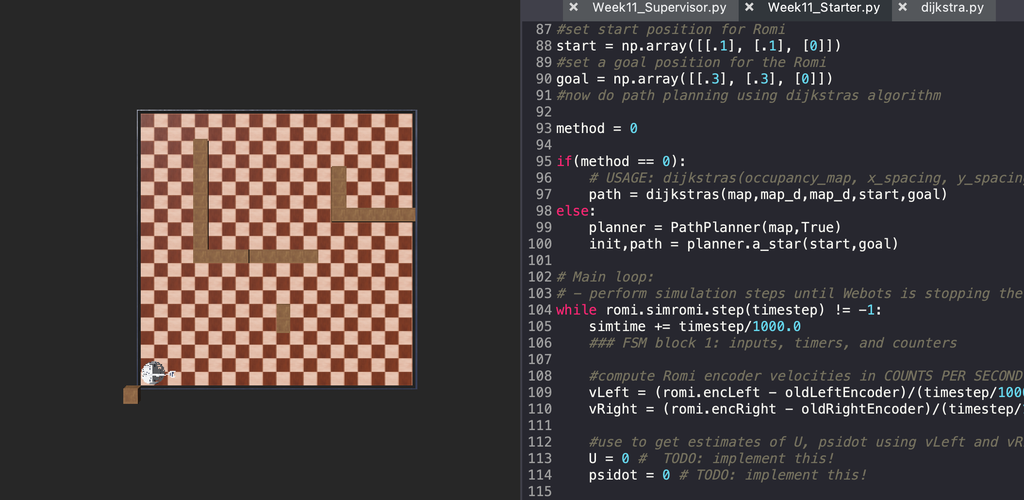

## Class Exercise: Follow a path generated by Dijkstra (or A star)!

The Week 11 starter controller already uses an implementation of the Dijkstra algorithm to plan a path between the Romi's start position in allocentric meters (line 88) to a user-specified allocentric goal, also in meters. It uses a black and white image to generate a "maze" in the world, and uses it as the path for Dijkstra. The path is specified as a list of allocentric goal coordinates:

```
Start Pose:  1 19
Goal Pose:  3 17
Goal found!
Generating path...
Path:
[[0.1, 0.1], [0.15, 0.05], [0.15, 0.15], [0.15, 0.25], [0.25, 0.25], [0.3, 0.3]]
```

## Class Exercise: Follow a path generated by Dijkstra (or A star)!

The Week 11 starter controller is "dumb" with respect to Romi motion, however. Your task is to modify its FSM so that the romi follows the path by subsequently using each point as a goal location for **feedback controllers** on distance and relative yaw angle.

1. Create an FSM that loops through the goal path points, switching to the next when the Romi is within an acceptable error of each goal
2. Implement a feedback controller that makes the Romi get to each point. You can use "perfect" GPS and IMU sensing if you want rather than your odometry estimates.